# Logistic Regression

Data Science for Biologists, Spring 2020

Nicholas Paterna

## Instructions

Standard grading criteria apply. Make sure you set your seed, and **proofread to submit YOUR OWN WORDS!!**

This assignment will use an external dataset of various physical measurements from 752 adult Pima Native American women, some of whom are type II diabetic and some are not. Our goal for this assignment is to build and evaluate a model from this data to **predict whether an individual has Type II Diabetes** (column `diabetic`).

```r
pima <- read_csv("https://raw.githubusercontent.com/sjspielman/datascience_for_biologists/master/data/pima.csv")
## Parsed with column specification:
## cols(
##   npreg = col_double(),
##   glucose = col_double(),
##   dbp = col_double(),
##   skin = col_double(),
##   insulin = col_double(),
##   bmi = col_double(),
##   age = col_double(),
##   diabetic = col_character()
## )
dplyr::glimpse(pima)
## Observations: 752
## Variables: 8
## $ npreg    <dbl> 6, 1, 8, 1, 0, 5, 3, 10, 2, 4, 10, 10, 1, 5, 7, 0, 7, 1, 1, …
## $ glucose  <dbl> 148, 85, 183, 89, 137, 116, 78, 115, 197, 110, 168, 139, 189…
## $ dbp      <dbl> 72, 66, 64, 66, 40, 74, 50, 0, 70, 92, 74, 80, 60, 72, 0, 84…
## $ skin     <dbl> 35, 29, 0, 23, 35, 0, 32, 0, 45, 0, 0, 0, 23, 19, 0, 47, 0, …
## $ insulin  <dbl> 0, 0, 0, 94, 168, 0, 88, 0, 543, 0, 0, 0, 846, 175, 0, 230, …
## $ bmi      <dbl> 33.6, 26.6, 23.3, 28.1, 43.1, 25.6, 31.0, 35.3, 30.5, 37.6, …
## $ age      <dbl> 50, 31, 32, 21, 33, 30, 26, 29, 53, 30, 34, 57, 59, 51, 32, …
## $ diabetic <chr> "Yes", "No", "Yes", "No", "Yes", "No", "Yes", "No", "Yes", "…

# Not severely imbalanced. ROC will be fine.
pima %>%
  count(diabetic)
## # A tibble: 2 x 2
##   diabetic     n
##   <chr>    <int>
## 1 No         488
## 2 Yes        264
```

Columns include:

- `npreg`: number of times pregnant
- `glucose`: plasma glucose concentration at 2 hours in an oral glucose tolerance test (units: mg/dL)
- `dpb`: diastolic blood pressure (units: mm Hg)
- `skin`: triceps skin-fold thickness (units: mm)
- `insulin`: 2-hour serum insulin level (units: μU/mL)
- `bmi`: Body Mass Index
- `age`: age in years
- `diabetic`: whether or not the individual has diabetes

## Part 1: Build THREE models

First, you will build THREE distinct models (without stepwise model selection - just build them!) from the full data set.

1. The first model should include *all columns as predictors* (except `diabetic`, of course)
2. The second model should include these two predictors ONLY:
- `glucose`
- `bmi`
3. The third model should include these three predictors ONLY (same as #2, but with `skin` added into the mix):
- `glucose`
- `bmi`
- `skin`

**Before you begin**, modify the `diabetic` column so that **Yes** is a “success” and **No** is a “failure.” Rather than recoding as 1/0, instead let’s just make the column a factor *with levels ordered Yes, No*! This will ensure “Yes” (has diabetes) is a success in the model.

```r
## Re-factor the diabetic column
## It is OK to overwrite the original pima dataset and the original diabetic column!!!!!!!!!!
#FAILURE FIRST (0), SUCCESS SECOND (1)
pima$diabetic <- factor(pima$diabetic, levels = c("No", "Yes"))

## Show the output to prove to yourself that the factoring worked
head(pima, 10)
```

```
## # A tibble: 10 x 8
##    npreg glucose   dbp  skin insulin   bmi   age diabetic
##    <dbl>   <dbl> <dbl> <dbl>   <dbl> <dbl> <dbl> <fct>
##  1     6     148    72    35       0  33.6    50 Yes
##  2     1      85    66    29       0  26.6    31 No
##  3     8     183    64     0       0  23.3    32 Yes
##  4     1      89    66    23      94  28.1    21 No
##  5     0     137    40    35     168  43.1    33 Yes
##  6     5     116    74     0       0  25.6    30 No
##  7     3      78    50    32      88  31      26 Yes
##  8    10     115     0     0       0  35.3    29 No
##  9     2     197    70    45     543  30.5    53 Yes
## 10     4     110    92     0       0  37.6    30 No
```

```r
## Build model 1
model1 <- glm(diabetic ~ ., data = pima, family = "binomial")

## Build model 2
model2 <- glm(diabetic ~ glucose + bmi, data = pima, family = "binomial")

## Build model 3
model3 <- glm(diabetic ~ glucose + bmi + skin, data = pima, family = "binomial")
```

## Part 2: Compare the three models from part 1

- In the space below, determine the AUC associated with each model.

```r
## Run roc() on each fitted model
model1_roc <- roc(pima$diabetic, model1$fitted.values)
model2_roc <- roc(pima$diabetic, model2$fitted.values)
model3_roc <- roc(pima$diabetic, model3$fitted.values)
## Reveal the three models' AUC values here
## Including [[1]] displays only the value, not the supplemental message
model1_roc$auc[[1]]
```

```
## [1] 0.8385029
```

```r
model2_roc$auc[[1]]
```

```
## [1] 0.8186243
```

```r
model3_roc$auc[[1]]
```

```
## [1] 0.8197536
```

```r
## Model has the best AUC making it the best model out of the three
```

- Then, plot an ROC curve of all three models in the same panel:
  - Model curves should be distinguished by color
  - Ensure that the models are *ordered* from best to worst in the legend, using AUC to determine this ranking.
  - Models should be named in the legend as *Model X (AUC=…)*. For example, imagine model 1 has an AUC of 0.7 - it should appear in the legend as *Model 1 (AUC = 0.7)*. HINT: Just put whatever the appropriate phrase is as the name of the model when wrangling!!
  - **Do not hardcode AUC values.** Always use a VARIABLE. To specifically get the auc value, do something like `roc_output$auc[[1]]` (the two square brackets!).

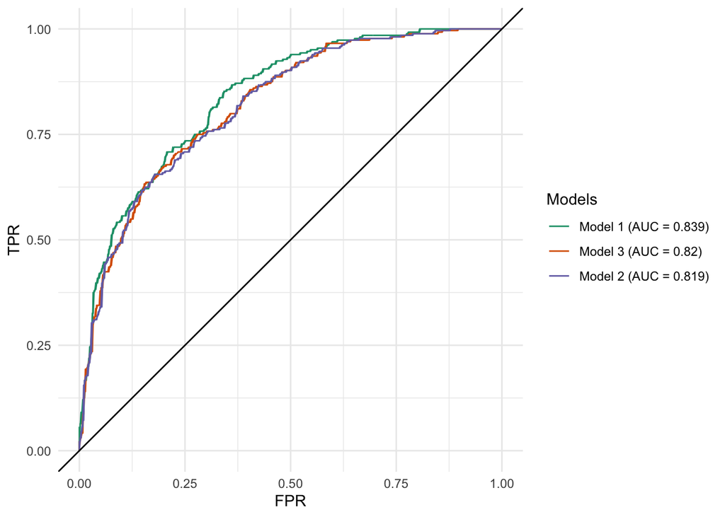

```r
## Plot the ROC curves below (which includes some wrangling!!)
tibble(FPR = 1 - model1_roc$specificities,
       TPR = model1_roc$sensitivities,
       model = paste0("Model 1 (AUC = ", round(model1_roc$auc[[1]], 3),")"),
       auc = model1_roc$auc[[1]]) -> model1_tibble

tibble(FPR = 1 - model2_roc$specificities,
       TPR = model2_roc$sensitivities,
       model = paste0("Model 2 (AUC = ", round(model2_roc$auc[[1]], 3),")"),
       auc = model2_roc$auc[[1]]) -> model2_tibble

tibble(FPR = 1 - model3_roc$specificities,
       TPR = model3_roc$sensitivities,
       model = paste0("Model 3 (AUC = ", round(model3_roc$auc[[1]], 3),")"),
       auc = model3_roc$auc[[1]]) -> model3_tibble

bind_rows(model1_tibble, model2_tibble, model3_tibble) %>%
  mutate(model_fct = factor(model)) %>%
  ggplot(aes(x = FPR, y = TPR,
             color = fct_reorder(model, auc, .desc = TRUE))) +
  geom_line() + geom_abline() +
  scale_color_brewer(palette = "Dark2") +
  labs(color = "Models") +
  theme_minimal()
```

#### Part 2 Questions

Answer each in 1-2 sentences each *that are CLEARLY WRITTEN in YOUR OWN WORDS without ELEMENTARY-SCHOOL-LEVEL TYPOS.* We! Are! In! College!

1. Which model has the highest AUC value, and what is its AUC? Given that AUC can range 0.5-1, do you believe this is highly accurate model?
- Model 1 has the **highest** AUC value of 0.839, this makes it a highly accurate model as it is fairly close to 1.
2. Compare models 2 and 3. What are the AUC values for each? Does including `skin` in the model seem to improve the model’s performance?
- Model 3 **(AUC = 0.8198)** has a higher AUC value than Model 2 **(AUC = 0.8186)** making it the better of the two. The inclusion of *skin* was not a favorable addition to this model as it did not increase the AUC by a signifiant amount (~ 0.0012).

## Part 3: Work with the best model

Determine the best model (highest AUC) from Parts 1 and 2, and use this model for Part 3. Perform the following tasks:

- Evaluate it with a training and testing split, where *75%* of the data is in the training split. Do NOT hardcode this 75% value!

```r
## Training and testing code goes here
training_percent <- 0.75

training_data <- sample_frac(pima, training_percent)
testing_data <- anti_join(pima, training_data)
#training split
train_model <- glm(diabetic ~., data = training_data, family = "binomial")
train_roc <- roc(training_data$diabetic, train_model$fitted.values)
train_roc$auc
```

```
## Area under the curve: 0.8472
```

```r
#testing split
test_model <- glm(diabetic ~., data = testing_data, family = "binomial")
test_roc <- roc(testing_data$diabetic, test_model$fitted.values)
test_roc$auc
```

```
## Area under the curve: 0.826
```

- Plot the logistic regression curve for the training and testing models you build. This will be two plots, which you should add together with patchwork to display, OR use some wrangling skills to make a faceted plot in the first place.
  - Do NOT!! color the logistic curve line
  - DO add colored points for individual observations along the curve
  - Rugs are optional

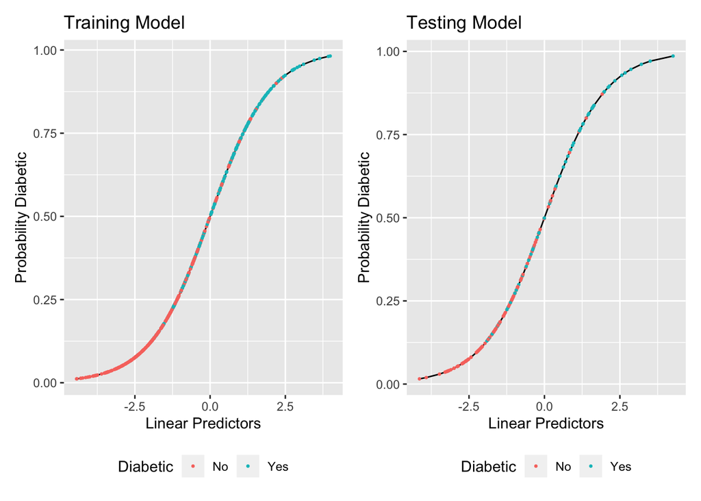

```r
## Plotting, and associated wrangling for plotting, goes here

##TRAINING
tibble(x = train_model$linear.predictors,
       y = train_model$fitted.values,
       diabetic = training_data$diabetic) %>%
  ggplot(aes(x = x, y = y)) +
  geom_line() +
  geom_point(aes(color = diabetic), size = 0.5) +
  theme(legend.position = "bottom") +
  labs(x = "Linear Predictors",
       y = "Probability Diabetic",
       title = "Training Model",
       color = "Diabetic") -> train_plot

##TESTING
tibble(x = test_model$linear.predictors,
       y = test_model$fitted.values,
       diabetic = testing_data$diabetic) %>%
  ggplot(aes(x = x, y = y)) +
  geom_line() +
  geom_point(aes(color = diabetic), size = 0.5) +
  theme(legend.position = "bottom") +
  labs(x = "Linear Predictors",
       y = "Probability Diabetic",
       title = "Testing Model",
       color = "Diabetic") -> test_plot

train_plot + test_plot
```

- Determine the AUC value for each, and plot the ROC curves for training and testing in the space below. Again, use one plotting panel and distinguish the fits with colors.

```r
## ROC for training/testing goes here
train_roc$auc
```

```
## Area under the curve: 0.8472
```

```r
## Area under the curve: 0.8472
test_roc$auc
```

```
## Area under the curve: 0.826
```

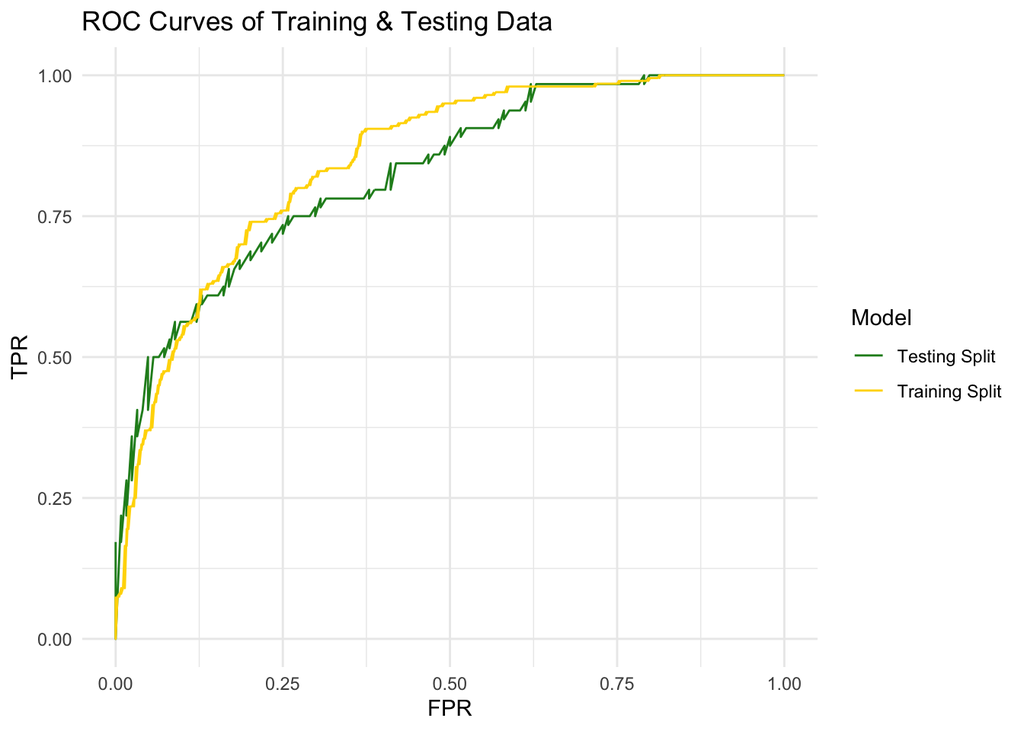

```r
## Area under the curve: 0.826


train_data <- tibble(FPR = 1 - train_roc$specificities,
                     TPR = train_roc$sensitivities,
                     model = "Training Split")

test_data <- tibble(FPR = 1 - test_roc$specificities,
                    TPR = test_roc$sensitivities,
                    model = "Testing Split")

bind_rows(train_data, test_data) %>%
  #Combines data
  ggplot(aes(x = FPR, y = TPR)) +
  geom_line(aes(color = model)) +
  scale_color_manual(values = c("forestgreen", "gold")) +
  labs(title = "ROC Curves of Training & Testing Data",
       color = "Model") +
  theme_minimal()
```

#### Part 3 Question

How does this model perform when considering a training and testing split? Compare their specific AUC values and discuss whether you believe the model suffers from overfitting or not in 1-2 sentences.

- This model performs well when considering the split, the resulting AUC of both the training split (~85%) and the testing split (~83%) are high but not clearly over-fitted as these values are not vastly different.

## Part 4: Evaluating at a given threshold

Determine the following measures for the best model (the FULL fit from part 1, NOT a training/testing split from part 3!!) assuming a *success threshold of 0.8*. Refer to the slides for formulas!

```r
threshold <- 0.8

model1 <- glm(diabetic ~ ., data = pima, family = "binomial")

## Code to calculate goes here
tibble(prob_diabetic = model1$fitted.values,
       truth = pima$diabetic,
       prediction = if_else(prob_diabetic >= threshold, "Yes", "No")) %>%
  mutate(classif = case_when(truth == "Yes" & prediction == "Yes" ~ "TP",
                             truth == "No" & prediction == "No" ~ "TN",
                             truth == "Yes" & prediction == "No" ~ "FN",
                             truth == "No" & prediction == "Yes" ~ "FP")) %>%
  count(classif) %>%
  pivot_wider(names_from = classif,
              values_from = n) -> final_p4
final_p4
```

```
## # A tibble: 1 x 4
##      FN    FP    TN    TP
##   <int> <int> <int> <int>
## 1   202    12   476    62
```

```r
## Calculating Accuracy = 0.715
## High threshold leads to moderate accuracy
final_p4 %>%
  mutate(Accuracy = (TP + TN) / (TP + TN + FP + FN))
```

```
## # A tibble: 1 x 5
##      FN    FP    TN    TP Accuracy
##   <int> <int> <int> <int>    <dbl>
## 1   202    12   476    62    0.715
```

```r
## Calculating FPR = 0.0246
final_p4 %>%
  mutate(FPR = FP / (TN + FP))
```

```
## # A tibble: 1 x 5
##      FN    FP    TN    TP    FPR
##   <int> <int> <int> <int>  <dbl>
## 1   202    12   476    62 0.0246
```

```r
## Calculating PPV = 0.838
final_p4 %>%
  mutate(TPR = TP / (TP + FP))
```

```
## # A tibble: 1 x 5
##      FN    FP    TN    TP   TPR
##   <int> <int> <int> <int> <dbl>
## 1   202    12   476    62 0.838
```

## Part 5: Predicting outcomes

Determine the probability that these two new women have diabetes, again using the best model. Here is their data (choose which columns to include in your tibbles based on what’s needed for the best model):

- Female 1
  - `npreg`: 5
  - `glucose`: 110
  - `dpb`: 78
  - `skin`: 20
  - `insulin`: 58
  - `bmi`: 25
  - `age`: 26
- Female 2
  - `npreg`: 3
  - `glucose`: 175
  - `dpb`: 92
  - `skin`: 28
  - `insulin`: 222
  - `bmi`: 38
  - `age`: 45

```r
## code to predict goes here
## make sure to predict PROBABILITIES!!!
## your code MUST PRINT OUT the probabilities for each woman in the end

tribble( ~npreg,  ~glucose,  ~dbp,  ~skin,  ~insulin,  ~bmi,  ~age,
         5,        110,        78,    20,     58,        25,     26,
         3,        175,        92,    28,     222,      38,      45) -> new_pima

predict(model1, new_pima, type = "response")
```

```
##         1         2
## 0.1063922 0.7978826
```

#### Part 5 Questions:

1. At a threshold of 80%, does the model predict that Woman 1 is diabetic? Answer yes or no!
- With a threshold of **80%** Woman 1 is *not* diabetic, her response was ~11%.
2. At a threshold of 80%, does the model predict that Woman 2 is diabetic? Answer yes or no!
- With a threshold of **80%** Woman 2 is *not* diabetic, her response was ~79.8%.